# ODE

Wenmin Zhang

30/01/2020

## Q1

A heuristic explanation will be that if the population achieves equilibrium than it can only be stable at $\frac{r-1}{r}$ or 0. Since the population size cannot go negative, thus 0 will be the stable point $r=0.5$ and 0.64 will be the stable point when $r=2.8$. The oscillation behavior at $r=3.3$ could due to that the change in the system is too rapid to reach a stable point.

```r
num=matrix(0,51,3)
num[1,]=rep(0.1,3)
rate = c(0.5,2.8,3.3)

for (c in 1:3)
  for (r in 1:50)
    num[r+1,c] = rate[c]*num[r,c]*(1-num[r,c])
```

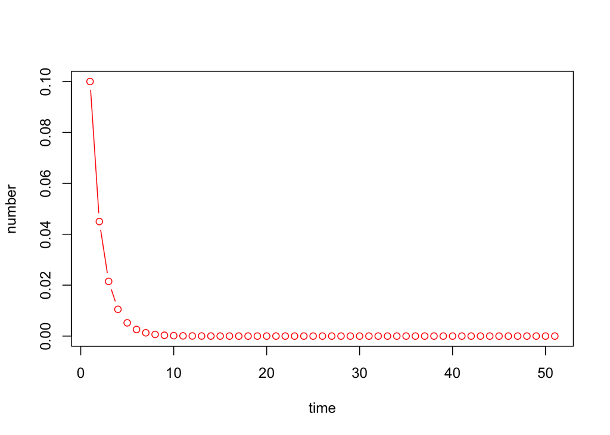

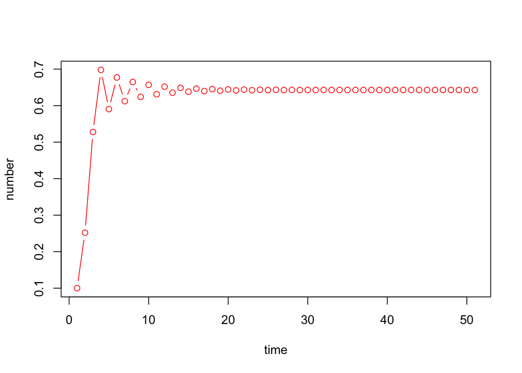

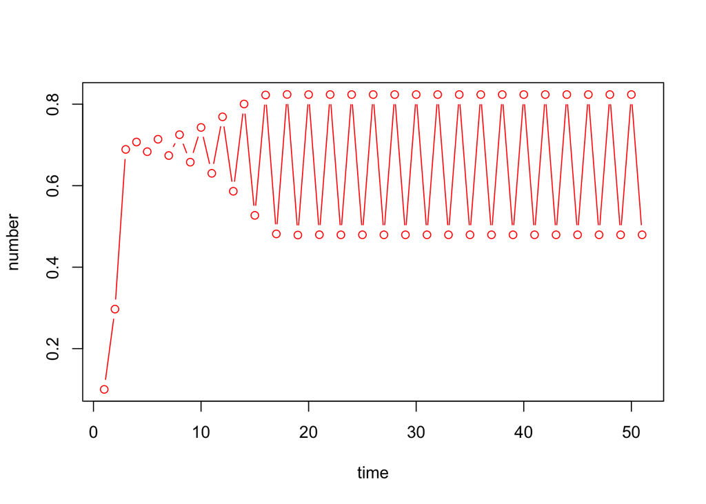

```r
for (i in 1:3)
  plot(1:51,num[,i],type="b",col="red",xlab="time",ylab="number")
```

## Q2

As the step size gets smaller, the estimate gets closer to the true value. This is expected since the appproximate procedure gets more accurate.

```r
integrate <- function(x0,t,h){
  x = x0
  ite = t/h
  for (i in 1:ite)
    x = x + h*x
    ite=ite+1
    return(x)
}
```

```r
integrate(1,5,0.1)
```

```
## [1] 117.3909
```

```r
integrate(1,5,0.01)
```

```
## [1] 144.7728
```

```r
integrate(1,5,0.001)
```

```
## [1] 148.0428
```

## Q3

```r
Cu=0.5
h=0.01
t=400
e=0.08
b=0.8
a=0.7
ite = t/h
v = rep(0,ite+1)
w = rep(0,ite+1)
v[1]=1
w[1]=0.1
```

```r
for (i in 1:ite) {
  dw = (e * (v[i] + a - b*w[i]))*h
  dv = (v[i] - (v[i]^3)/3 -w[i] + Cu)*h
  w[i+1] <- w[i] + dw
  v[i+1] <- v[i] + dv
#  cat(i,collapse="\n")
#  cat(dw,collapse="\n")
#  cat(dv,collapse="\n")
}
```

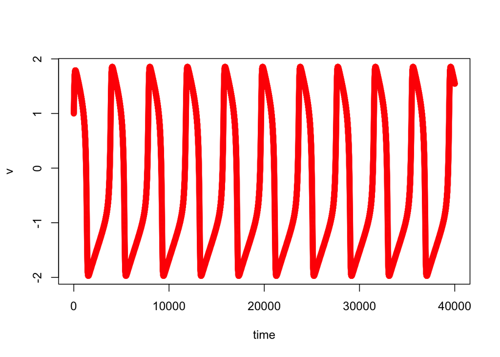

```r
plot(1:(ite+1),v,type="b",col="red",xlab="time",ylab="v")
```

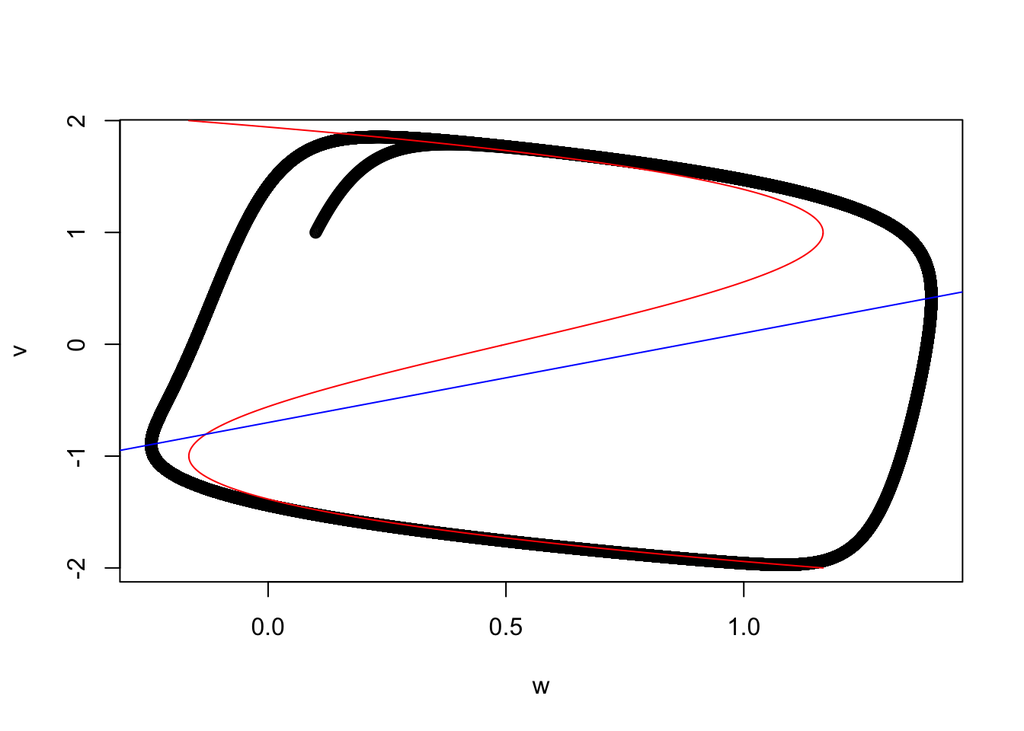

```r
plot(w,v)
v0 <- seq(-2,2,by = 0.01)
w0 <- v0 - v0^3 / 3 + Cu
lines(w0,v0,col="red")
w1 <- (v0 + a)/b
lines(w1,v0,col="blue")
```

```r
#v - v^3/3 - (v + a)/b + Cu
polyroot(c(-a/b+Cu,1-1/b,0,-1/3))
```

```
## [1]  0.4024239+1.111681i -0.8048477-0.000000i  0.4024239-1.111681i
```

The Jacobian matrix has the following entries accordingly: $1-v^2$, $-1$, $\epsilon$, $-b\epsilon$.

We can alternatively guess the sign of the eigenvalues from the spiral shape of the trajectory.

```r
vstar = polyroot(c(-a/b+Cu,1-1/b,0,-1/3))
eigen(matrix(c(1-vstar[2]^2,e,-1,-b*e),2,2))
```

```
## eigen() decomposition
## $values
## [1] 0.1441101-0.1915469i 0.1441101+0.1915469i
##
## $vectors
##                      [,1]                 [,2]
## [1,] 0.9622504+0.0000000i 0.9622504+0.0000000i
## [2,] 0.2002540+0.1843161i 0.2002540-0.1843161i
```

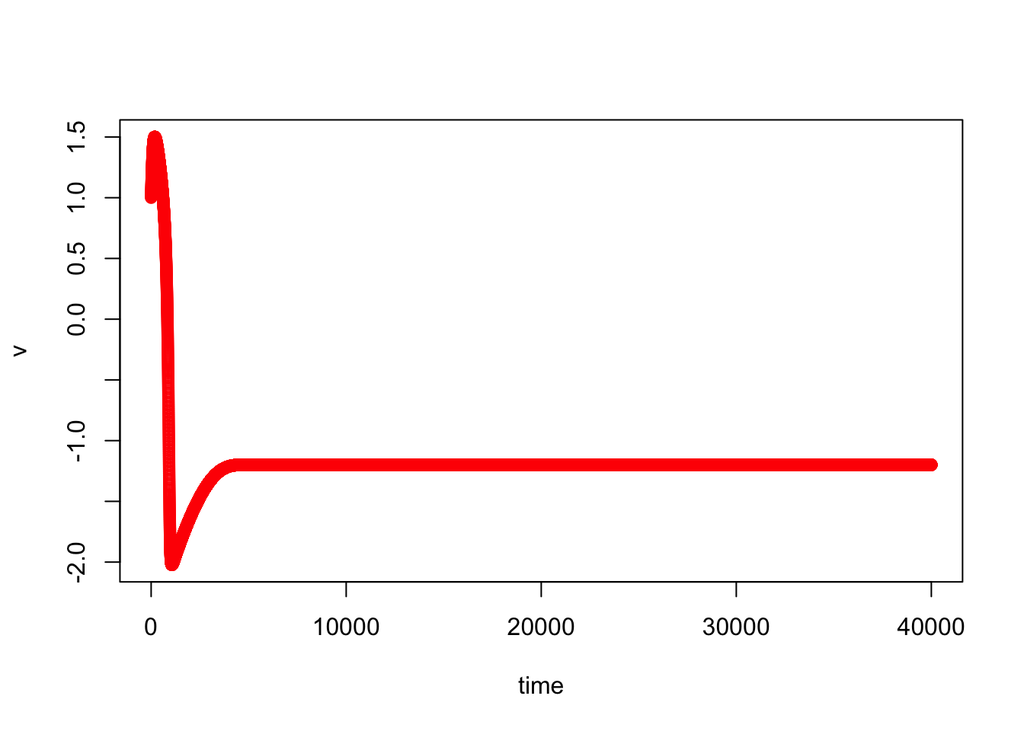

```r
Cu = 0
for (i in 1:ite) {
  dw = (e * (v[i] + a - b*w[i]))*h
  dv = (v[i] - (v[i]^3)/3 -w[i] + Cu)*h
  w[i+1] <- w[i] + dw
  v[i+1] <- v[i] + dv
#  cat(i,collapse="\n")
#  cat(dw,collapse="\n")
#  cat(dv,collapse="\n")
}
plot(1:(ite+1),v,type="b",col="red",xlab="time",ylab="v")
```

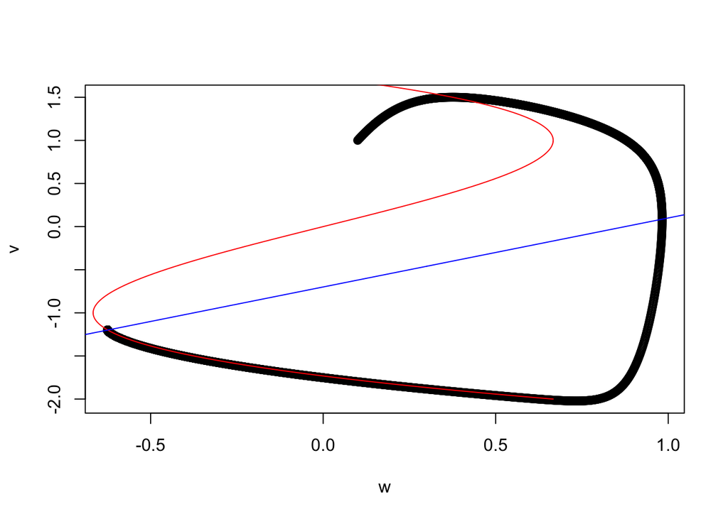

```r
plot(w,v)
v0 <- seq(-2,2,by = 0.01)
w0 <- v0 - v0^3 / 3 + Cu
lines(w0,v0,col="red")
w1 <- (v0 + a)/b
lines(w1,v0,col="blue")
```

```r
polyroot(c(-a/b+Cu,1-1/b,0,-1/3))
```

```
## [1]  0.599704+1.352381i -1.199408+0.000000i  0.599704-1.352381i
```

```r
vstar = polyroot(c(-a/b+Cu,1-1/b,0,-1/3))
eigen(matrix(c(1-vstar[2]^2,e,-1,-b*e),2,2))
```

```
## eigen() decomposition
## $values
## [1] -0.2512898+0.2119493i -0.2512898-0.2119493i
##
## $vectors
##                       [,1]                  [,2]
## [1,]  0.9622504+0.0000000i  0.9622504+0.0000000i
## [2,] -0.1802197-0.2039484i -0.1802197+0.2039484i
```

```r
vs=c()
for (Cu in seq(0,0.5,0.01)){
  vs = c(vs,polyroot(c(-a/b+Cu,1-1/b,0,-1/3))[2])
}
```

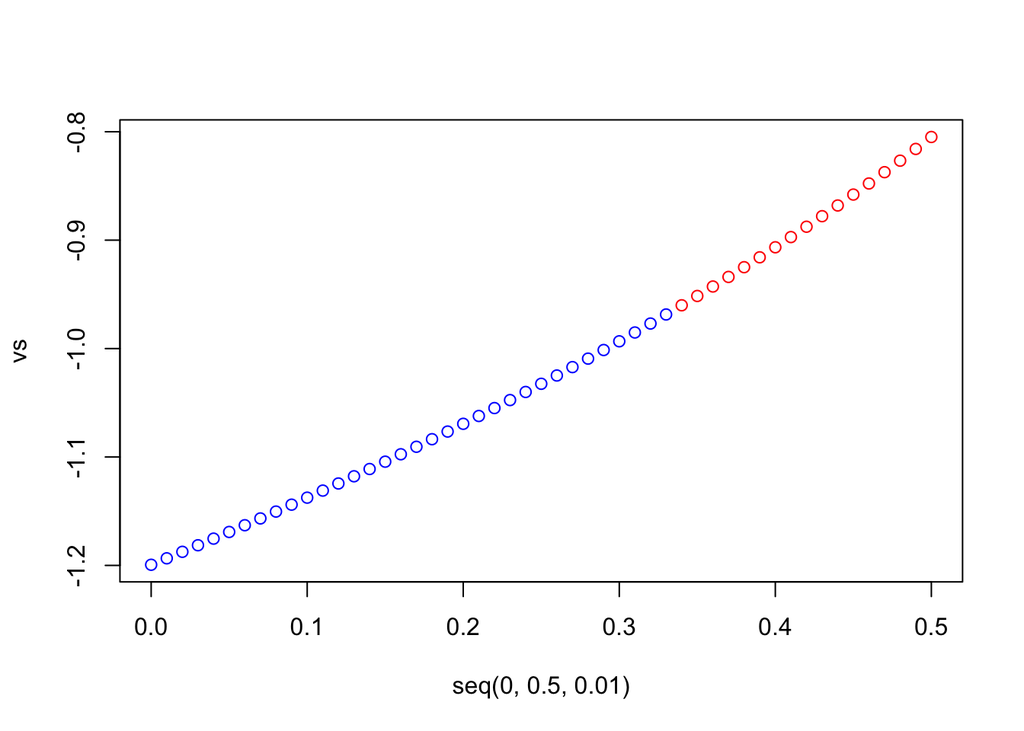

```r
vseigen <- c()
for (vst in vs){
  tmp = eigen(matrix(c(1-vst^2,e,-1,-b*e),2,2))
#  cat(tmp$values)
  vseigen <- c(vseigen,Re(tmp$values[1]))
}
plot(seq(0,0.5,0.01),vs,col=ifelse(vseigen>0,"red","blue"))
```